# HW 09 - Ch6

Author

Kristy Feinberg

## Set Up

```r
library(tidyverse)
# Set our ggplot theme from the outset
theme_set(theme_light())
# Read in the data
gender_employment <- read_csv("https://raw.githubusercontent.com/vaiseys/dav-course/main/Data/gender_employment.csv")
# Glimpse at the data
glimpse(gender_employment)
```

```
Rows: 2,088
Columns: 12
$ year                  <dbl> 2013, 2013, 2013, 2013, 2013, 2013, 2013, 2013, …
$ occupation            <chr> "Chief executives", "General and operations mana…
$ major_category        <chr> "Management, Business, and Financial", "Manageme…
$ minor_category        <chr> "Management", "Management", "Management", "Manag…
$ total_workers         <dbl> 1024259, 977284, 14815, 43015, 754514, 44198, 10…
$ workers_male          <dbl> 782400, 681627, 8375, 17775, 440078, 16141, 7287…
$ workers_female        <dbl> 241859, 295657, 6440, 25240, 314436, 28057, 3683…
$ percent_female        <dbl> 23.6, 30.3, 43.5, 58.7, 41.7, 63.5, 33.6, 27.5, …
$ total_earnings        <dbl> 120254, 73557, 67155, 61371, 78455, 74114, 62187…
$ total_earnings_male   <dbl> 126142, 81041, 71530, 75190, 91998, 90071, 66579…
$ total_earnings_female <dbl> 95921, 60759, 65325, 55860, 65040, 66052, 55079,…
$ wage_percent_of_male  <dbl> 76.04208, 74.97316, 91.32532, 74.29179, 70.69719…
```

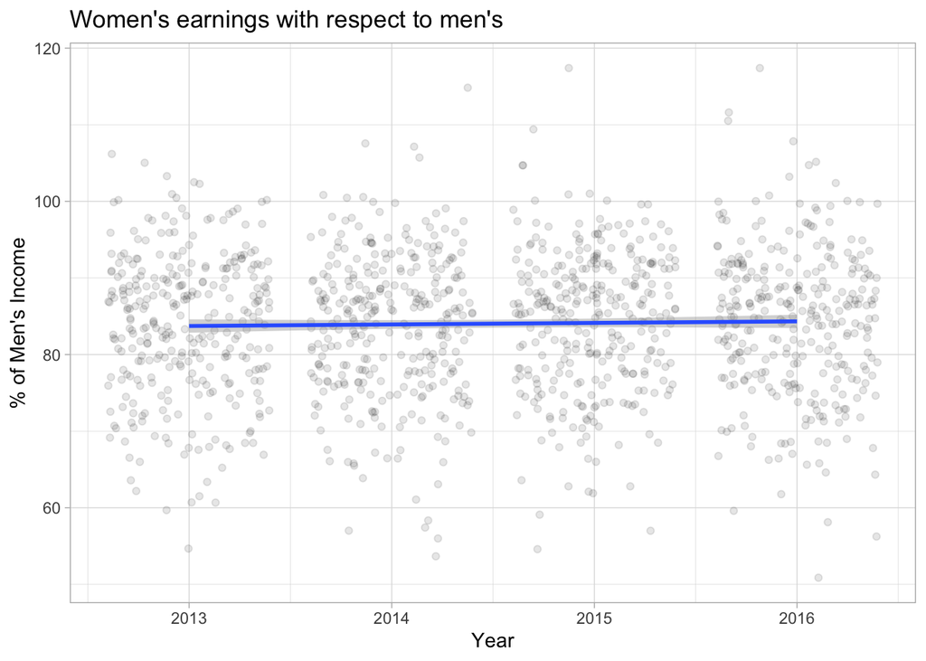

```r
gender_employment%>%
  ggplot(aes(x = year, y = wage_percent_of_male)) +
  geom_jitter(alpha = 0.1) +
  geom_smooth(method = "lm") +
  labs(title = "Women's earnings with respect to men's",
       y = "% of Men's Income",
       x = "Year")
```

We will be observing how this relationship varies across occupations

## Question 1

Relevel to make major_category the central variable

```r
gender_employment <- gender_employment %>%
  mutate(major_category = as.factor(major_category),
         major_category = relevel(major_category, ref = "Management, Business, and Financial"))
```

Now, fit the model described above and save it as `parallel_model`. Using `tidy()` from the `broom` package, summarize the results. Can we say anything about overall trends by year?

```r
library(dplyr)
library(broom)
parallel_model <- lm(wage_percent_of_male ~ year + major_category, data = gender_employment)

broom:: tidy(parallel_model)
```

```
# A tibble: 9 × 5
  term                                     estimate std.error statistic  p.value
  <chr>                                       <dbl>     <dbl>     <dbl>    <dbl>
1 (Intercept)                              -307.      459.       -0.669 5.04e- 1
2 year                                        0.192     0.228     0.844 3.99e- 1
3 major_categoryComputer, Engineering, an…    6.32      0.946     6.68  3.56e-11
4 major_categoryEducation, Legal, Communi…    5.76      0.985     5.84  6.53e- 9
5 major_categoryHealthcare Practitioners …    5.52      1.10      5.00  6.41e- 7
6 major_categoryNatural Resources, Constr…    4.91      1.24      3.95  8.15e- 5
7 major_categoryProduction, Transportatio…   -1.31      0.960    -1.37  1.72e- 1
8 major_categorySales and Office              3.33      0.858     3.88  1.11e- 4
9 major_categoryService                       6.08      0.885     6.87  1.03e-11
```

**Can we say anything about overall trends by year?**

The regression looks something like wage percent of males = -306.718 + 0.1922(year). Year would be 2000, 2020, etc. With each one additional year we expect the percentage for the baseline category to increase by 0.1922

**Now you do some interpretation. Using the coefficients from your model, calculate the wage percentage of male income for Sales and Office occupations on 2015.**

**Now calculate the wage percentage of male income for Service occupations on 2016.**

wage percent of males = -306.718 + 0.1922(year) + major category = -306.718+0.1922(2016)+6.077 = 86.8342

## Question 2

**Using the code from the introductory section, make a similar plot but facet it by major category so that lines vary across categories. What do you notice? Is the parallel trends assumption warranted?**

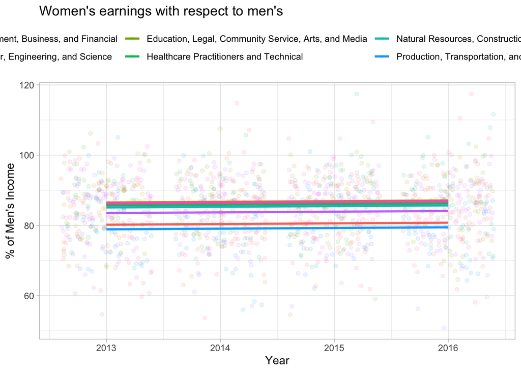

```r
library(moderndive)
gender_employment%>%
  ggplot(aes(x = year, y = wage_percent_of_male, group = major_category,colour=major_category)) +
  geom_jitter(alpha = 0.1) +
  labs(title = "Women's earnings with respect to men's",
       y = "% of Men's Income",
       x = "Year") +
  geom_parallel_slopes(se = FALSE) +  # this is a modern dive thing!
  theme(legend.position = "top")
```

## Question 3

**Let’s fit another model that includes an interaction between `major_category` and `year`. This will allow the slopes to differ across major categories. Again, use `tidy()` to get the summary of the results.**

```r
library(dplyr)
library(broom)
two_var_model <- lm(wage_percent_of_male ~ year*major_category, data = gender_employment)

broom:: tidy(two_var_model)
```

```
# A tibble: 16 × 5
   term                                     estimate std.error statistic p.value
   <chr>                                       <dbl>     <dbl>     <dbl>   <dbl>
 1 (Intercept)                              -1.37e+3  1106.       -1.24    0.216
 2 year                                      7.20e-1     0.549     1.31    0.190
 3 major_categoryComputer, Engineering, an…  1.00e+3  1703.        0.589   0.556
 4 major_categoryEducation, Legal, Communi…  1.94e+3  1774.        1.09    0.275
 5 major_categoryHealthcare Practitioners …  9.06e+2  1987.        0.456   0.649
 6 major_categoryNatural Resources, Constr… -2.89e+3  2232.       -1.29    0.196
 7 major_categoryProduction, Transportatio…  1.58e+3  1735.        0.909   0.363
 8 major_categorySales and Office            1.61e+3  1541.        1.05    0.296
 9 major_categoryService                     2.14e+3  1595.        1.34    0.180
10 year:major_categoryComputer, Engineerin… -4.95e-1     0.845    -0.585   0.559
11 year:major_categoryEducation, Legal, Co… -9.59e-1     0.880    -1.09    0.276
12 year:major_categoryHealthcare Practitio… -4.47e-1     0.986    -0.453   0.651
13 year:major_categoryNatural Resources, C…  1.44e+0     1.11      1.30    0.195
14 year:major_categoryProduction, Transpor… -7.84e-1     0.861    -0.910   0.363
15 year:major_categorySales and Office      -7.98e-1     0.765    -1.04    0.297
16 year:major_categoryService               -1.06e+0     0.792    -1.34    0.182
```

**So tell me what the estimate would be for “Computer, Engineering, and Science” for 2016. What about the same estimate but for “Service”? Do you notice any differences?**

**“Computer, Engineering, and Science”** = -1370.472+0.72(year)-0.495(year)+major_category = -1370.472+0.72(2016)-0.495(year)+1002.853 = 85.981

**“Service”** = -1370.472+0.72(year)-1.06(year)+major_category = -1370.472+0.72(2016)-1.06(2016)+2137.650 = 81.738

The wage percent for service workers was 86.83 and now it is 81.738. This means the initial regression over estimates the value of wage percentage for service works in 2016. A parallel slope shouldn’t be an accurate prediction.

## Question 4

**Given that we have the ability to add interactions to models - i.e. to have slopes vary across categories -, why would we choose to build a model that assumes parallel trends?**

I would not use a parallel trends model unless you know the two variables are related or for simplicity sake. “all other things being equal, simpler solutions are more likely to be correct than complex ones.” There is a chance we are adding complexity when it is not relevant.

## Question 5

**Let’s now think about a model that includes two continuous variables as explanatory variables. Here, we are still interested in predicting how `wage_percent_of_male` has changed across years. Let’s start simple: build a model where `wage_percent_of_male` is the outcome variable and `year` is the explanatory variable and save it as `simple_fit`. Then, use `tidy()` to look at the model output. Briefly, describe the results.**

```r
library(dplyr)
library(broom)
simple_fit <- lm(wage_percent_of_male ~ year, data = gender_employment)

broom::tidy(simple_fit)
```

```
# A tibble: 2 × 5
  term        estimate std.error statistic p.value
  <chr>          <dbl>     <dbl>     <dbl>   <dbl>
1 (Intercept) -322.      479.       -0.671   0.502
2 year           0.201     0.238     0.847   0.397
```

The equation would look like -321.83+0.201(year). Each additional year adds .2 to the total wage percentage.

**Let’s add the other variable in there. We want a model that takes into account the variable `percent_female`. This variable records what percentage of the workforce of a given occupation is made up of women. The thinking behind this addition is that the proportion of women in an industry might affect how much the gender paygap has changed across the last few years.**

**Before we build the model we want to explore the relationship between these variables. Like in the chapter, use `select()` and `cor()` to find the correlations between these three variables. Because we have some missing values, you want to give `cor()` the argument `use = "complete.obs"`.**

```r
gender_employment %>%
  select(year, wage_percent_of_male, percent_female) %>%
  cor(use = "complete.obs")
```

```
                            year wage_percent_of_male percent_female
year                 1.000000000           0.02403895    0.004998286
wage_percent_of_male 0.024038950           1.00000000    0.111464461
percent_female       0.004998286           0.11146446    1.000000000
```

**Describe the relationships between the variables.**

**What we want to to know, however, is the relationship between year and the paygap conditional on the proportion of women who work in an occupation. This is where the model described above comes handy. Build that model and save it as `multiple_fit`. Then, use `tidy()` to summarize the results. Describe the results in your own words. Is this what you would have expected?**

```r
multiple_fit <- lm(wage_percent_of_male ~ year*percent_female, data = gender_employment)

get_regression_table(multiple_fit) %>% select(term,estimate)
```

```
# A tibble: 4 × 2
  term                estimate
  <chr>                  <dbl>
1 intercept           -800.
2 year                   0.438
3 percent_female        10.6
4 year:percent_female   -0.005
```

the wage percentage of male = -800.111+0.438(year)+10.637(female)-0.005(female)(year)

A 1% increase in female’s in an industry leads to a 0.56 percent change in the wage percentage of males (in 2016). This isn’t what I would expect. I would expect the higher percent of females the lower the wage percent of males.

## Question 6

**Here, we will practice some model comparison and I will also introduce you to another useful tool from the `broom` package.**

**First, let’s review the discussion about R squared. Briefly tell me, in your own words, what R squared is.**

R^2 is a statistical value that measures the proportion of variance in the dependent variable that can be explained by the independent variable. It can be calculated by 1-(sum of squares of residuals/total sum of squares)

```r
simple_glanced <- glance(simple_fit)
```

**And then you can access the R squared, the same way you would access a column from a dataframe, with the `$` sign.**

```r
simple_glanced$r.squared
```

```
[1] 0.0005778711
```

**Do this for both models and compare the R squared. What can you conclude from this?**

```r
simple_glanced <- glance(multiple_fit)
simple_glanced$r.squared
```

```
[1] 0.01321338
```

R^2 for the multiple_fit model is 0.0132 while the R^2 value for the single_fit model is 0.000577. Statistically this means that the independent variables in the multiple_fit do a better job of explaining changes in the dependent variable.

## A Warning Sign

```r
random_numbers <- rnorm(n = nrow(gender_employment),
                        mean = 0,
                        sd = 4)
```

```r
gender_employment$random_noise <- random_numbers

# New model
random_fit <- lm(wage_percent_of_male ~ year + percent_female + random_noise, data = gender_employment)
```